# Note S1: Analysis of mutations shared by oocytes of the same animal

Marzia A. Cremona

```r
library(readxl)
library(writexl)
library(PoissonBinomial)
```

# Mutations shared by oocytes from the same animal

We observed 56 mutation sites (corresponding to 117 mutations) shared by oocytes of the same animal. In order to understand how likely it is to observe such shared mutations by random chance, we build a probabilistic model which takes into consideration the generally higher mutation rate in D-loop than outside D-loop, the number of sequenced oocytes (with mean DCS depth of at least 100×) in each animal and the mean DCS depth of each sequenced oocyte. Using this model, we are able to compute the expected number of shared mutation sites in each of the 29 animals (with sequenced oocytes) in our study.

## Mutation frequency estimation

We estimate the random mutation frequency per nucleotide for our macaque oocyte samples in a conservative way, by counting only mutations found in exactly one oocyte of each macaque and dividing it by the total number of sequenced nucleotides (computed as the sum over all oocytes of the mean sequencing depth for that oocyte times the mtDNA length). Since D-loop generally shows a higher mutation frequency, we estimate this frequency separately for D-loop ($p_{D}$) and for the nucleotides outside of D-loop ($p_{nonD}$). Only oocytes with mean sequencing depth of at least 100x are considered (a total of 119 oocytes among 29 macaques).

Mutation frequency estimation:

```r
n_mut_D = 719
n_mut_nonD = 1116
nt_seq_D = 94814895
nt_seq_nonD = 1352663373

p_D = n_mut_D / nt_seq_D
p_D
```

```
[1] 7.583197e-06
```

```r
p_nonD = n_mut_nonD / nt_seq_nonD
p_nonD
```

```
[1] 8.25039e-07
```

We obtain a random mutation frequency $p_{D}=7.58 \times 10^{-6}$ in the D-loop and $p_{nonD}=8.25 \times 10^{-7}$ outside of the D-loop.

## Probability of calling a mutation in a certain oocyte

We model the process of having a random mutation in a nucleotide of a single molecule as Bernoulli trial $X \sim B(1,p)$, where the probability $p$ is $p_{D}$ for the nucleotides in the D-loop and $p_{nonD}$ for the nucleotides outside the D-loop.

We assume that mutations occur independently in different sequenced molecules, hence the number of mutations per nucleotide in an oocyte is $Y \sim B(d,p)$, where $d$ is the mean sequencing depth of that oocyte. For each oocyte, we can then compute the probability of calling a mutation in a nucleotide as $q = P(Y \geq 1)$.

```r
mut2 <- read_excel("2020-09_Rh_mut_freqs.xlsx", sheet = "Rh_mut_freq")

# select only oocytes with mean depth >= 100x
mut_Oo <- subset(mut2, (mean_depth_DCS >= 100) & (tissue == "oocyte") )
```

Number of oocytes:

```r
nrow(mut_Oo)
```

```
[1] 119
```

Number of macaques:

```r
length(unique(mut_Oo$macaque_ID))
```

```
[1] 29
```

Number of oocytes for each macaque:

```r
n_Oo = table(mut_Oo$macaque_ID)
n_Oo
```

```
Rh015 Rh016 Rh017 Rh020 Rh023 Rh024 Rh025 Rh026 Rh027 Rh029 Rh064 Rh066 Rh067 Rh068 Rh072 Rh074 Rh081 Rh083 Rh084 Rh086 Rh088 Rh094 Rh096 Rh097 Rh098 Rh102 Rh104 Rh105
    2     2     5     2     2    10     2     2     2     2    10     2     1     2     2     2    11     2     2     2     2    12     2     2     7     2    10    11
Rh106
    4
```

Statistics of number of oocytes for each macaque:

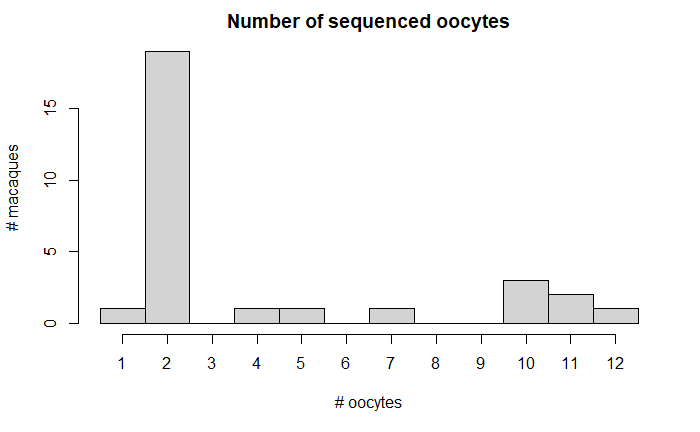

```r
hist(n_Oo, breaks = seq(0.5, max(n_Oo)+0.5), xlim = c(0,max(n_Oo))+0.5, xaxt = "n",
     main = "Number of sequenced oocytes", xlab = "# oocytes", ylab = "# macaques")
axis(side = 1, at = 1:max(n_Oo))
```

```r
summary(as.numeric(n_Oo))
```

```
   Min. 1st Qu.  Median    Mean 3rd Qu.    Max.
  1.000   2.000   2.000   4.103   5.000  12.000
```

Compute the probability of calling a mutation in a nucleotide of D-loop $q_{D}$ and in a nucleotide outside of D-loop $q_{nonD}$:

```r
mut_Oo$q_D = 1 - pbinom(0, size = mut_Oo$mean_depth_DCS, prob = p_D)
mut_Oo$q_nonD = 1 - pbinom(0, size = mut_Oo$mean_depth_DCS, prob = p_nonD)
```

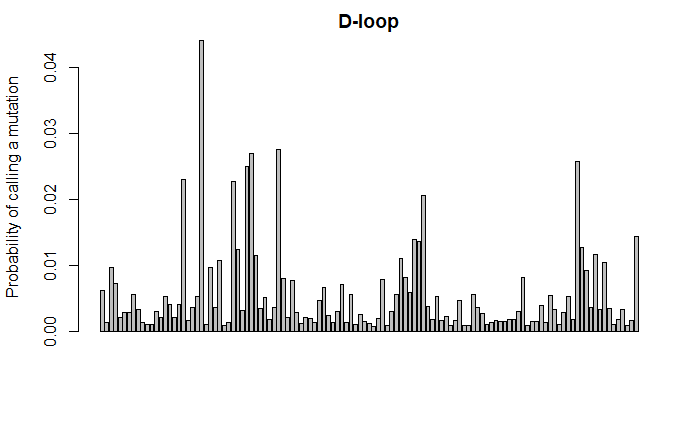

```r
barplot(mut_Oo$q_D, ylab = "Probability of calling a mutation", main = "D-loop")
```

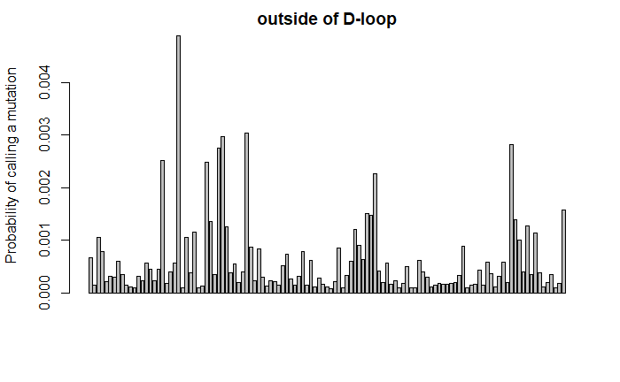

```r
barplot(mut_Oo$q_nonD, ylab = "Probability of calling a mutation", main = "outside of D-loop")
```

## Probability of observing the same mutation in multiple oocytes of the same macaque

For each macaque, we consider the number of oocyes sequenced $n_{Oo}$ (which ranges from 1 to 12). The number of oocytes of the same macaque with a mutation in a certain nucleotide is $W = W_1 + \dots + W_{n_{Oo}}$ with $W_i \sim B(1, q_i)$. Assuming independence, we can model $W$ with the Poisson binomial distribution $W \sim PB(n_{Oo}, q_1, \dots, q_{n_{Oo}})$. **We can then compute the probability of observing the same mutation in two or more oocytes of the same macaque by random chance as $s = P(W \geq 2)$**.

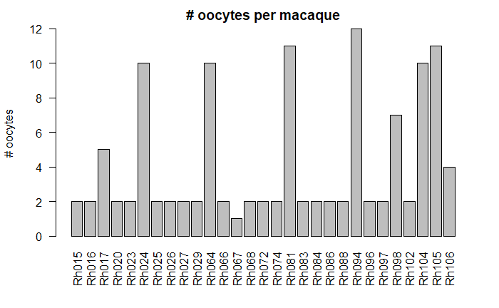

```r
barplot(n_Oo, las = 2, ylab = "# oocytes", main = "# oocytes per macaque")
```

```r
prob_shared_Oo = cbind(tapply(mut_Oo$q_D, mut_Oo$macaque_ID,
                              function(q_i){
                                1 - ppbinom(1, probs = q_i)
                              }),
                       tapply(mut_Oo$q_nonD, mut_Oo$macaque_ID,
                              function(q_i){
                                1 - ppbinom(1, probs = q_i)
                              }))
colnames(prob_shared_Oo) = c('s_D', 's_nonD')
prob_shared_Oo
```

```
               s_D       s_nonD
Rh015 7.984335e-06 9.482577e-08
Rh016 6.981087e-05 8.326102e-07
Rh017 1.030450e-04 1.230375e-06
Rh020 1.259663e-06 1.492569e-08
Rh023 2.747118e-06 3.257369e-08
Rh024 3.111529e-03 3.872039e-05
Rh025 9.114111e-06 1.083981e-07
Rh026 3.770414e-05 4.491439e-07
Rh027 1.008067e-06 1.194341e-08
Rh029 2.794148e-04 3.359807e-06
Rh064 5.279641e-03 6.659251e-05
Rh066 1.613531e-05 1.918255e-07
Rh067 0.000000e+00 0.000000e+00
Rh068 2.438282e-06 2.890378e-08
Rh072 2.493042e-06 2.955243e-08
Rh074 3.120230e-05 3.712185e-07
Rh081 3.190530e-04 3.834615e-06
Rh083 1.486936e-05 1.767710e-07
Rh084 2.626904e-06 3.114858e-08
Rh086 6.078181e-05 7.248182e-07
Rh088 4.799740e-05 5.717246e-07
Rh094 1.981945e-03 2.438174e-05
Rh096 4.538677e-06 5.387820e-08
Rh097 9.754599e-06 1.157905e-07
Rh098 4.513558e-05 5.373129e-07
Rh102 2.440531e-05 2.903251e-07
Rh104 3.094408e-04 3.718053e-06
Rh105 2.867740e-03 3.556103e-05
Rh106 9.020898e-05 1.078133e-06
```

## Expected number of shared mutations

Finally, we can compute the expected number of random mutations present at the same site in two or more oocytes of the same macaque by multiplying the probability $p$ by the mtDNA length (i.e., 1085 nucleotides for D-loop and 15479 nucleotides outside of D-loop).

```r
nt_D = 1085
nt_nonD = 15479

expected_shared_Oo = t(t(prob_shared_Oo) * c(nt_D, nt_nonD))
expected_shared_Oo = cbind(expected_shared_Oo, rowSums(expected_shared_Oo))
colnames(expected_shared_Oo) = c('exp_mut_D', 'exp_mut_nonD', 'exp_mut_tot')
expected_shared_Oo
```

```
        exp_mut_D exp_mut_nonD exp_mut_tot
Rh015 0.008663004 0.0014678081 0.010130812
Rh016 0.075744799 0.0128879731 0.088632772
Rh017 0.111803775 0.0190449771 0.130848752
Rh020 0.001366734 0.0002310347 0.001597769
Rh023 0.002980623 0.0005042081 0.003484831
Rh024 3.376009114 0.5993529567 3.975362071
Rh025 0.009888811 0.0016778943 0.011566705
Rh026 0.040908988 0.0069522991 0.047861287
Rh027 0.001093753 0.0001848721 0.001278625
Rh029 0.303165060 0.0520064528 0.355171512
Rh064 5.728411022 1.0307854758 6.759196498
Rh066 0.017506811 0.0029692662 0.020476077
Rh067 0.000000000 0.0000000000 0.000000000
Rh068 0.002645536 0.0004474017 0.003092937
Rh072 0.002704951 0.0004574420 0.003162393
Rh074 0.033854500 0.0057460906 0.039600590
Rh081 0.346172532 0.0593560126 0.405528544
Rh083 0.016133257 0.0027362379 0.018869495
Rh084 0.002850191 0.0004821489 0.003332340
Rh086 0.065948269 0.0112194603 0.077167729
Rh088 0.052077184 0.0088497248 0.060926909
Rh094 2.150410635 0.3774049753 2.527815611
Rh096 0.004924465 0.0008339806 0.005758445
Rh097 0.010583740 0.0017923208 0.012376061
Rh098 0.048972109 0.0083170665 0.057289176
Rh102 0.026479764 0.0044939419 0.030973706
Rh104 0.335743266 0.0575517467 0.393295013
Rh105 3.111498090 0.5504491330 3.661947223
Rh106 0.097876741 0.0166884156 0.114565156
```

Observed number of shared mutations:

```r
shared_Oo = cbind(n_Oo, expected_shared_Oo, 0, 0)
colnames(shared_Oo)[5:6] = c("obs_mut_tot", "delta")
shared_Oo["Rh017","obs_mut_tot"] = 1
shared_Oo["Rh024","obs_mut_tot"] = 3
shared_Oo["Rh064","obs_mut_tot"] = 18
shared_Oo["Rh081","obs_mut_tot"] = 3
shared_Oo["Rh086","obs_mut_tot"] = 2
shared_Oo["Rh094","obs_mut_tot"] = 3
shared_Oo["Rh104","obs_mut_tot"] = 7
shared_Oo["Rh105","obs_mut_tot"] = 19
shared_Oo[,"delta"] = shared_Oo[,"obs_mut_tot"] - shared_Oo[,"exp_mut_tot"]
shared_Oo
```

```
      n_Oo   exp_mut_D exp_mut_nonD exp_mut_tot obs_mut_tot        delta
Rh015    2 0.008663004 0.0014678081 0.010130812           0 -0.010130812
Rh016    2 0.075744799 0.0128879731 0.088632772           0 -0.088632772
Rh017    5 0.111803775 0.0190449771 0.130848752           1  0.869151248
Rh020    2 0.001366734 0.0002310347 0.001597769           0 -0.001597769
Rh023    2 0.002980623 0.0005042081 0.003484831           0 -0.003484831
Rh024   10 3.376009114 0.5993529567 3.975362071           3 -0.975362071
Rh025    2 0.009888811 0.0016778943 0.011566705           0 -0.011566705
Rh026    2 0.040908988 0.0069522991 0.047861287           0 -0.047861287
Rh027    2 0.001093753 0.0001848721 0.001278625           0 -0.001278625
Rh029    2 0.303165060 0.0520064528 0.355171512           0 -0.355171512
Rh064   10 5.728411022 1.0307854758 6.759196498          18 11.240803502
Rh066    2 0.017506811 0.0029692662 0.020476077           0 -0.020476077
Rh067    1 0.000000000 0.0000000000 0.000000000           0  0.000000000
Rh068    2 0.002645536 0.0004474017 0.003092937           0 -0.003092937
Rh072    2 0.002704951 0.0004574420 0.003162393           0 -0.003162393
Rh074    2 0.033854500 0.0057460906 0.039600590           0 -0.039600590
Rh081   11 0.346172532 0.0593560126 0.405528544           3  2.594471456
Rh083    2 0.016133257 0.0027362379 0.018869495           0 -0.018869495
Rh084    2 0.002850191 0.0004821489 0.003332340           0 -0.003332340
Rh086    2 0.065948269 0.0112194603 0.077167729           2  1.922832271
Rh088    2 0.052077184 0.0088497248 0.060926909           0 -0.060926909
Rh094   12 2.150410635 0.3774049753 2.527815611           3  0.472184389
Rh096    2 0.004924465 0.0008339806 0.005758445           0 -0.005758445
Rh097    2 0.010583740 0.0017923208 0.012376061           0 -0.012376061
Rh098    7 0.048972109 0.0083170665 0.057289176           0 -0.057289176
Rh102    2 0.026479764 0.0044939419 0.030973706           0 -0.030973706
Rh104   10 0.335743266 0.0575517467 0.393295013           7  6.606704987
Rh105   11 3.111498090 0.5504491330 3.661947223          19 15.338052777
Rh106    4 0.097876741 0.0166884156 0.114565156           0 -0.114565156
```

Total number of expected shared mutations:

```r
colSums(shared_Oo[,2:4])
```

```
   exp_mut_D exp_mut_nonD  exp_mut_tot
   15.986418     2.834891    18.821309
```

**We expect to observe around 19 mutation sites shared by oocytes of the same macaque (16 in D-loop and 3 outside D-loop). We actually observe 56 shared sites (52 in D-loop and 4 outside D-loop).**

```r
plot(shared_Oo[,"exp_mut_tot"], shared_Oo[,"obs_mut_tot"], xlab = "Expected # mutations", ylab = "Observed # mutations", main = "Mutations shared by oocytes of the same macaque", xlim = c(0, 7.5))
abline(0, 1, lty = 3, col = "darkgray")
```

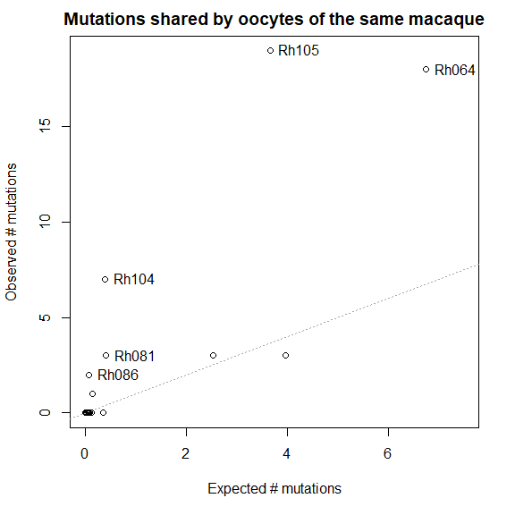

```r
index_text = which(shared_Oo[,"delta"] > 1)
text(shared_Oo[index_text,"exp_mut_tot"], shared_Oo[index_text,"obs_mut_tot"], row.names(shared_Oo)[index_text], pos = 4)
```